# One sample t-test

AGNR/SNR 220 comparing means - one sample

Author

Dr. Alejandro Molina

💻 Run Tasks 1–4 in **Excel**. If you do not have a laptop, you can complete these tasks by hand with a calculator, except Task 3.2. Complete Task 3.2 and the R tasks when you have access to a computer.

Normal human body temperature, as kids are taught in North America, is 98.6°F. But how well is this supported by data? Researchers obtained body-temperature measurements on randomly chosen healthy people (Shoemaker 1996). The data for 25 of those people are as follows:

| individual | temperature |
| --- | --- |
| 1 | 98.4 |
| 2 | 98.6 |
| 3 | 97.8 |
| 4 | 98.8 |
| 5 | 97.9 |
| 6 | 99.0 |
| 7 | 98.2 |
| 8 | 98.8 |
| 9 | 98.8 |
| 10 | 99.0 |
| 11 | 98.0 |
| 12 | 99.2 |
| 13 | 99.5 |
| 14 | 99.4 |
| 15 | 98.4 |
| 16 | 99.1 |
| 17 | 98.4 |
| 18 | 97.6 |
| 19 | 97.4 |
| 20 | 97.5 |
| 21 | 97.5 |
| 22 | 98.8 |
| 23 | 98.6 |
| 24 | 100.0 |
| 25 | 98.4 |

You can download the data from Canvas: `datatable.csv`

You are testing whether the population mean body temperature differs from 98.6°F. Use a significance level of $\alpha = 0.05$.

## Task 1

#### Excel 💻 or by hand

Write your null and alternative hypotheses. Define what $\mu$ represents. Write them in words and in symbols.

## Task 2

#### Excel 💻 or by hand

Calculate your t value! Use the following equation:

$$t = \frac{\bar{Y} - \mu_0}{SE_{\bar{Y}}}$$

Here, $\mu_0$ is the population mean specified by the null hypothesis.

In Excel, use `AVERAGE()` to calculate the sample mean and `STDEV.S()` to calculate the sample standard deviation. If you are working by hand, calculate these using your notes and a calculator.

Calculate the standard error using:

$$SE_{\bar{Y}} = \frac{s}{\sqrt{n}}$$

Here, $s$ is the sample standard deviation and $n$ is the sample size. In Excel, use `SQRT()` to calculate the square root.

Report:

- Sample size.
- Sample mean.
- Sample standard deviation.
- Standard error.
- t value.

Keep several decimal places during your calculations. Round your final t value to three decimal places.

## Task 3

Find a P-value.

### Task 3.1 Approximate P-value

**Read these instructions before opening the tables.**

The t distribution is symmetric and bell-shaped, with heavier tails than the normal distribution. These heavier tails account for the uncertainty from estimating the population standard deviation using a sample.

Its shape depends on the **degrees of freedom**, so different degrees of freedom require different tables. With more degrees of freedom, the t distribution gets closer to the standard normal distribution.

For a one-sample t-test:

$$df = n - 1$$

#### How to use the tables

1. Calculate your degrees of freedom and open the matching tab.
2. Find the absolute value of your t statistic, $|t|$. Use its distance from zero, regardless of whether it is positive or negative.
3. Compare $|t|$ with the critical t values in the table.
4. Read the corresponding **two-tailed probabilities**. If your value falls between two critical t values, your P-value falls between their probabilities.

For example, if $|t|$ falls between the critical values for probabilities of 0.10 and 0.05, report:

$$0.05 < P < 0.10$$

If $|t|$ is smaller than the first critical value, report $P > 0.50$. If it is larger than the last critical value, report $P < 0.001$.

**Remember! We are doing a two-tailed test.** The probabilities in these tables already include both tails. You do not need to double them.

Each graph shows the rejection regions for $\alpha = 0.05$. Each tail contains 0.025 of the total area. A t value in either shaded region leads us to reject the null hypothesis at this significance level.

**Report your degrees of freedom and the approximate P-value range from the appropriate table.**

*Click the box to open tha tables, after you have read the instructions*

**NoteShow or hide the t-tables and graphs**

**df = 5**

Use this table when your degrees of freedom equal 5. Compare your absolute t value with the critical values below and read across to find the two-tailed probability.

| Critical \|t\| | Two-tailed probability |
| --- | --- |
| 0.727 | 0.500 |
| 0.920 | 0.400 |
| 1.156 | 0.300 |
| 1.301 | 0.250 |
| 1.476 | 0.200 |
| 1.516 | 0.190 |
| 1.558 | 0.180 |
| 1.602 | 0.170 |
| 1.649 | 0.160 |
| 1.699 | 0.150 |
| 1.753 | 0.140 |
| 1.810 | 0.130 |
| 1.873 | 0.120 |
| 1.941 | 0.110 |
| 2.015 | 0.100 |
| 2.098 | 0.090 |
| 2.191 | 0.080 |
| 2.297 | 0.070 |
| 2.422 | 0.060 |
| 2.571 | 0.050 |
| 2.658 | 0.045 |
| 2.757 | 0.040 |
| 2.870 | 0.035 |
| 3.003 | 0.030 |
| 3.163 | 0.025 |
| 3.365 | 0.020 |
| 3.634 | 0.015 |
| 4.032 | 0.010 |
| 4.262 | 0.008 |
| 4.570 | 0.006 |
| 5.030 | 0.004 |
| 5.893 | 0.002 |
| 6.869 | 0.001 |

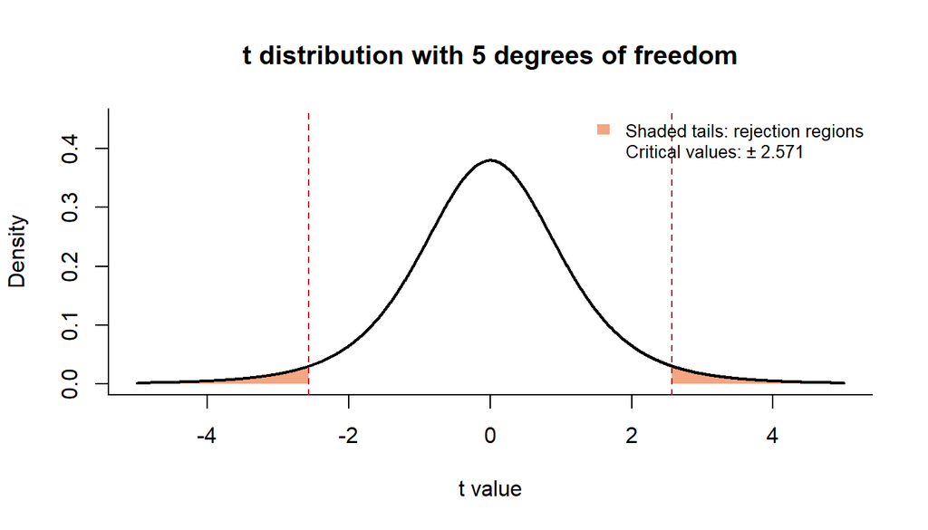

**df = 10**

Use this table when your degrees of freedom equal 10. Compare your absolute t value with the critical values below and read across to find the two-tailed probability.

| Critical \|t\| | Two-tailed probability |
| --- | --- |
| 0.700 | 0.500 |
| 0.879 | 0.400 |
| 1.093 | 0.300 |
| 1.221 | 0.250 |
| 1.372 | 0.200 |
| 1.406 | 0.190 |
| 1.442 | 0.180 |
| 1.479 | 0.170 |
| 1.518 | 0.160 |
| 1.559 | 0.150 |
| 1.603 | 0.140 |
| 1.650 | 0.130 |
| 1.700 | 0.120 |
| 1.754 | 0.110 |
| 1.812 | 0.100 |
| 1.877 | 0.090 |
| 1.948 | 0.080 |
| 2.028 | 0.070 |
| 2.120 | 0.060 |
| 2.228 | 0.050 |
| 2.290 | 0.045 |
| 2.359 | 0.040 |
| 2.437 | 0.035 |
| 2.527 | 0.030 |
| 2.634 | 0.025 |
| 2.764 | 0.020 |
| 2.932 | 0.015 |
| 3.169 | 0.010 |
| 3.301 | 0.008 |
| 3.472 | 0.006 |
| 3.716 | 0.004 |
| 4.144 | 0.002 |
| 4.587 | 0.001 |

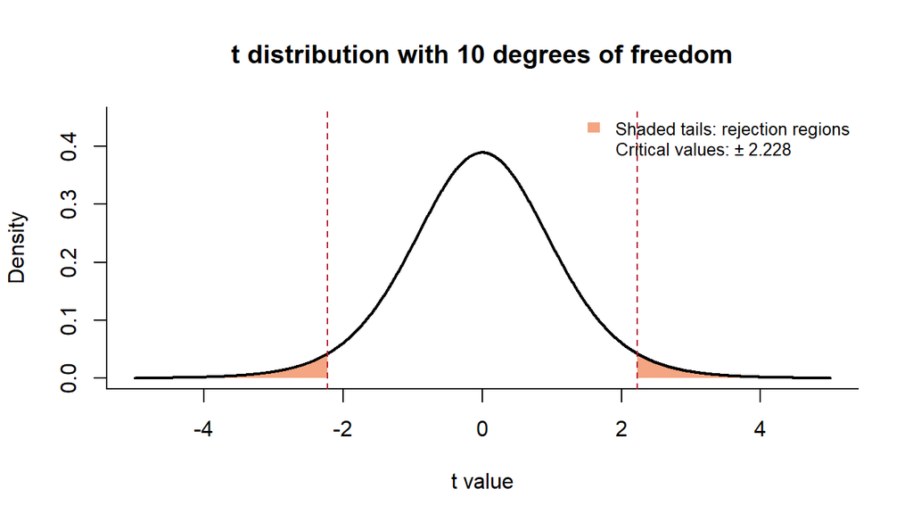

**df = 15**

Use this table when your degrees of freedom equal 15. Compare your absolute t value with the critical values below and read across to find the two-tailed probability.

| Critical \|t\| | Two-tailed probability |
| --- | --- |
| 0.691 | 0.500 |
| 0.866 | 0.400 |
| 1.074 | 0.300 |
| 1.197 | 0.250 |
| 1.341 | 0.200 |
| 1.373 | 0.190 |
| 1.406 | 0.180 |
| 1.441 | 0.170 |
| 1.478 | 0.160 |
| 1.517 | 0.150 |
| 1.558 | 0.140 |
| 1.602 | 0.130 |
| 1.649 | 0.120 |
| 1.699 | 0.110 |
| 1.753 | 0.100 |
| 1.812 | 0.090 |
| 1.878 | 0.080 |
| 1.951 | 0.070 |
| 2.034 | 0.060 |
| 2.131 | 0.050 |
| 2.187 | 0.045 |
| 2.249 | 0.040 |
| 2.318 | 0.035 |
| 2.397 | 0.030 |
| 2.490 | 0.025 |
| 2.602 | 0.020 |
| 2.746 | 0.015 |
| 2.947 | 0.010 |
| 3.056 | 0.008 |
| 3.197 | 0.006 |
| 3.395 | 0.004 |
| 3.733 | 0.002 |
| 4.073 | 0.001 |

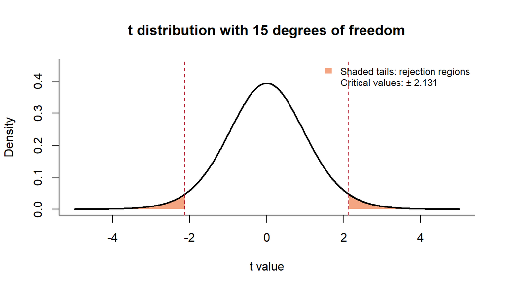

**df = 20**

Use this table when your degrees of freedom equal 20. Compare your absolute t value with the critical values below and read across to find the two-tailed probability.

| Critical \|t\| | Two-tailed probability |
| --- | --- |
| 0.687 | 0.500 |
| 0.860 | 0.400 |
| 1.064 | 0.300 |
| 1.185 | 0.250 |
| 1.325 | 0.200 |
| 1.357 | 0.190 |
| 1.389 | 0.180 |
| 1.424 | 0.170 |
| 1.459 | 0.160 |
| 1.497 | 0.150 |
| 1.537 | 0.140 |
| 1.579 | 0.130 |
| 1.624 | 0.120 |
| 1.672 | 0.110 |
| 1.725 | 0.100 |
| 1.782 | 0.090 |
| 1.844 | 0.080 |
| 1.914 | 0.070 |
| 1.994 | 0.060 |
| 2.086 | 0.050 |
| 2.139 | 0.045 |
| 2.197 | 0.040 |
| 2.262 | 0.035 |
| 2.336 | 0.030 |
| 2.423 | 0.025 |
| 2.528 | 0.020 |
| 2.661 | 0.015 |
| 2.845 | 0.010 |
| 2.945 | 0.008 |
| 3.073 | 0.006 |
| 3.251 | 0.004 |
| 3.552 | 0.002 |
| 3.850 | 0.001 |

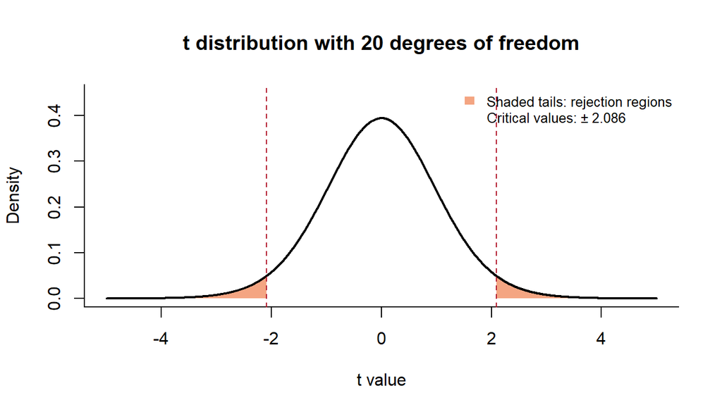

**df = 22**

Use this table when your degrees of freedom equal 22. Compare your absolute t value with the critical values below and read across to find the two-tailed probability.

| Critical \|t\| | Two-tailed probability |
| --- | --- |
| 0.686 | 0.500 |
| 0.858 | 0.400 |
| 1.061 | 0.300 |
| 1.182 | 0.250 |
| 1.321 | 0.200 |
| 1.352 | 0.190 |
| 1.385 | 0.180 |
| 1.419 | 0.170 |
| 1.454 | 0.160 |
| 1.492 | 0.150 |
| 1.531 | 0.140 |
| 1.573 | 0.130 |
| 1.618 | 0.120 |
| 1.665 | 0.110 |
| 1.717 | 0.100 |
| 1.773 | 0.090 |
| 1.835 | 0.080 |
| 1.905 | 0.070 |
| 1.983 | 0.060 |
| 2.074 | 0.050 |
| 2.126 | 0.045 |
| 2.183 | 0.040 |
| 2.247 | 0.035 |
| 2.320 | 0.030 |
| 2.405 | 0.025 |
| 2.508 | 0.020 |
| 2.639 | 0.015 |
| 2.819 | 0.010 |
| 2.916 | 0.008 |
| 3.041 | 0.006 |
| 3.214 | 0.004 |
| 3.505 | 0.002 |
| 3.792 | 0.001 |

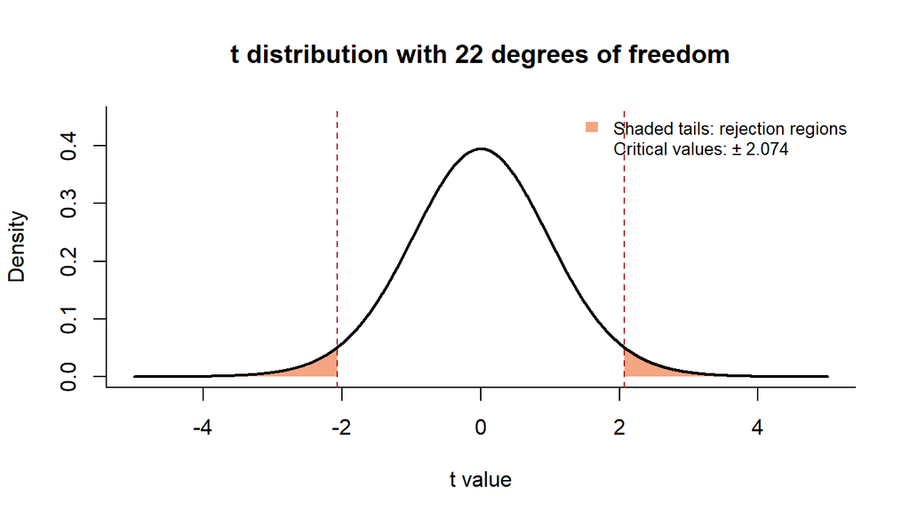

**df = 24**

Use this table when your degrees of freedom equal 24. Compare your absolute t value with the critical values below and read across to find the two-tailed probability.

| Critical \|t\| | Two-tailed probability |
| --- | --- |
| 0.685 | 0.500 |
| 0.857 | 0.400 |
| 1.059 | 0.300 |
| 1.179 | 0.250 |
| 1.318 | 0.200 |
| 1.349 | 0.190 |
| 1.381 | 0.180 |
| 1.415 | 0.170 |
| 1.450 | 0.160 |
| 1.487 | 0.150 |
| 1.526 | 0.140 |
| 1.568 | 0.130 |
| 1.612 | 0.120 |
| 1.660 | 0.110 |
| 1.711 | 0.100 |
| 1.767 | 0.090 |
| 1.828 | 0.080 |
| 1.896 | 0.070 |
| 1.974 | 0.060 |
| 2.064 | 0.050 |
| 2.115 | 0.045 |
| 2.172 | 0.040 |
| 2.235 | 0.035 |
| 2.307 | 0.030 |
| 2.391 | 0.025 |
| 2.492 | 0.020 |
| 2.620 | 0.015 |
| 2.797 | 0.010 |
| 2.892 | 0.008 |
| 3.014 | 0.006 |
| 3.183 | 0.004 |
| 3.467 | 0.002 |
| 3.745 | 0.001 |

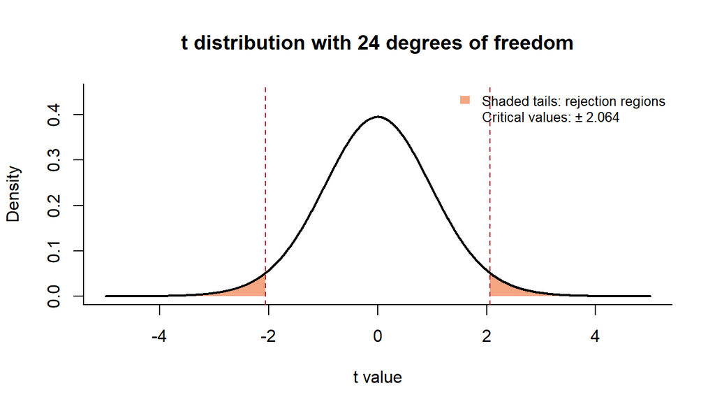

**df = 25**

Use this table when your degrees of freedom equal 25. Compare your absolute t value with the critical values below and read across to find the two-tailed probability.

| Critical \|t\| | Two-tailed probability |
| --- | --- |
| 0.684 | 0.500 |
| 0.856 | 0.400 |
| 1.058 | 0.300 |
| 1.178 | 0.250 |
| 1.316 | 0.200 |
| 1.347 | 0.190 |
| 1.379 | 0.180 |
| 1.413 | 0.170 |
| 1.448 | 0.160 |
| 1.485 | 0.150 |
| 1.524 | 0.140 |
| 1.566 | 0.130 |
| 1.610 | 0.120 |
| 1.657 | 0.110 |
| 1.708 | 0.100 |
| 1.764 | 0.090 |
| 1.825 | 0.080 |
| 1.893 | 0.070 |
| 1.970 | 0.060 |
| 2.060 | 0.050 |
| 2.110 | 0.045 |
| 2.167 | 0.040 |
| 2.229 | 0.035 |
| 2.301 | 0.030 |
| 2.385 | 0.025 |
| 2.485 | 0.020 |
| 2.612 | 0.015 |
| 2.787 | 0.010 |
| 2.882 | 0.008 |
| 3.003 | 0.006 |
| 3.170 | 0.004 |
| 3.450 | 0.002 |
| 3.725 | 0.001 |

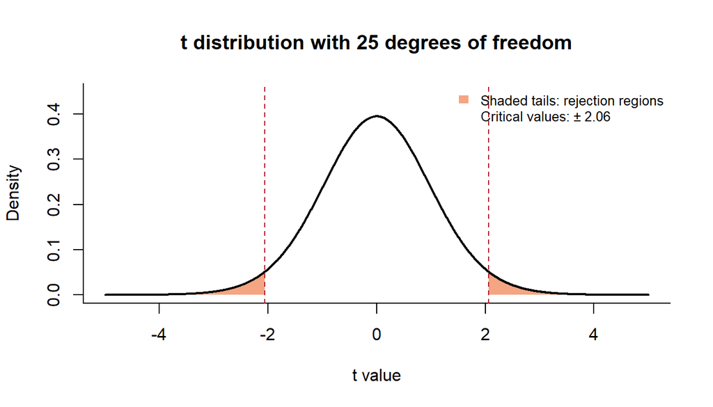

**df = 30**

Use this table when your degrees of freedom equal 30. Compare your absolute t value with the critical values below and read across to find the two-tailed probability.

| Critical \|t\| | Two-tailed probability |
| --- | --- |
| 0.683 | 0.500 |
| 0.854 | 0.400 |
| 1.055 | 0.300 |
| 1.173 | 0.250 |
| 1.310 | 0.200 |
| 1.341 | 0.190 |
| 1.373 | 0.180 |
| 1.406 | 0.170 |
| 1.441 | 0.160 |
| 1.477 | 0.150 |
| 1.516 | 0.140 |
| 1.557 | 0.130 |
| 1.600 | 0.120 |
| 1.647 | 0.110 |
| 1.697 | 0.100 |
| 1.752 | 0.090 |
| 1.812 | 0.080 |
| 1.879 | 0.070 |
| 1.955 | 0.060 |
| 2.042 | 0.050 |
| 2.092 | 0.045 |
| 2.147 | 0.040 |
| 2.208 | 0.035 |
| 2.278 | 0.030 |
| 2.360 | 0.025 |
| 2.457 | 0.020 |
| 2.581 | 0.015 |
| 2.750 | 0.010 |
| 2.841 | 0.008 |
| 2.957 | 0.006 |
| 3.118 | 0.004 |
| 3.385 | 0.002 |
| 3.646 | 0.001 |

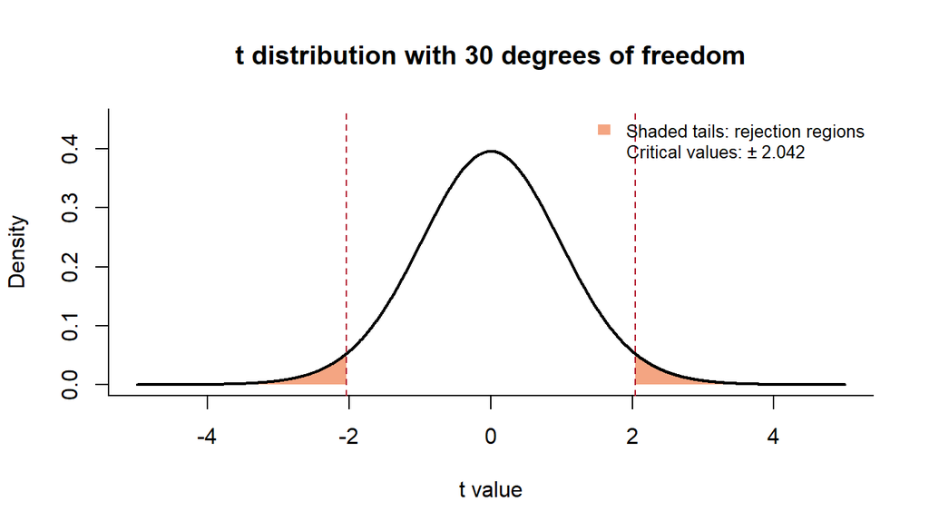

**df = 35**

Use this table when your degrees of freedom equal 35. Compare your absolute t value with the critical values below and read across to find the two-tailed probability.

| Critical \|t\| | Two-tailed probability |
| --- | --- |
| 0.682 | 0.500 |
| 0.852 | 0.400 |
| 1.052 | 0.300 |
| 1.170 | 0.250 |
| 1.306 | 0.200 |
| 1.337 | 0.190 |
| 1.368 | 0.180 |
| 1.401 | 0.170 |
| 1.436 | 0.160 |
| 1.472 | 0.150 |
| 1.510 | 0.140 |
| 1.551 | 0.130 |
| 1.594 | 0.120 |
| 1.640 | 0.110 |
| 1.690 | 0.100 |
| 1.744 | 0.090 |
| 1.803 | 0.080 |
| 1.869 | 0.070 |
| 1.944 | 0.060 |
| 2.030 | 0.050 |
| 2.079 | 0.045 |
| 2.133 | 0.040 |
| 2.194 | 0.035 |
| 2.262 | 0.030 |
| 2.342 | 0.025 |
| 2.438 | 0.020 |
| 2.558 | 0.015 |
| 2.724 | 0.010 |
| 2.813 | 0.008 |
| 2.926 | 0.006 |
| 3.081 | 0.004 |
| 3.340 | 0.002 |
| 3.591 | 0.001 |

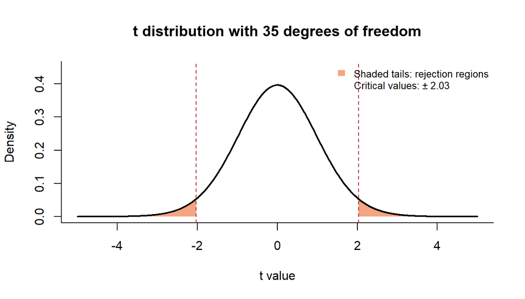

**df = 40**

Use this table when your degrees of freedom equal 40. Compare your absolute t value with the critical values below and read across to find the two-tailed probability.

| Critical \|t\| | Two-tailed probability |
| --- | --- |
| 0.681 | 0.500 |
| 0.851 | 0.400 |
| 1.050 | 0.300 |
| 1.167 | 0.250 |
| 1.303 | 0.200 |
| 1.333 | 0.190 |
| 1.365 | 0.180 |
| 1.397 | 0.170 |
| 1.432 | 0.160 |
| 1.468 | 0.150 |
| 1.506 | 0.140 |
| 1.546 | 0.130 |
| 1.589 | 0.120 |
| 1.635 | 0.110 |
| 1.684 | 0.100 |
| 1.737 | 0.090 |
| 1.796 | 0.080 |
| 1.862 | 0.070 |
| 1.936 | 0.060 |
| 2.021 | 0.050 |
| 2.070 | 0.045 |
| 2.123 | 0.040 |
| 2.183 | 0.035 |
| 2.250 | 0.030 |
| 2.329 | 0.025 |
| 2.423 | 0.020 |
| 2.542 | 0.015 |
| 2.704 | 0.010 |
| 2.792 | 0.008 |
| 2.902 | 0.006 |
| 3.055 | 0.004 |
| 3.307 | 0.002 |
| 3.551 | 0.001 |

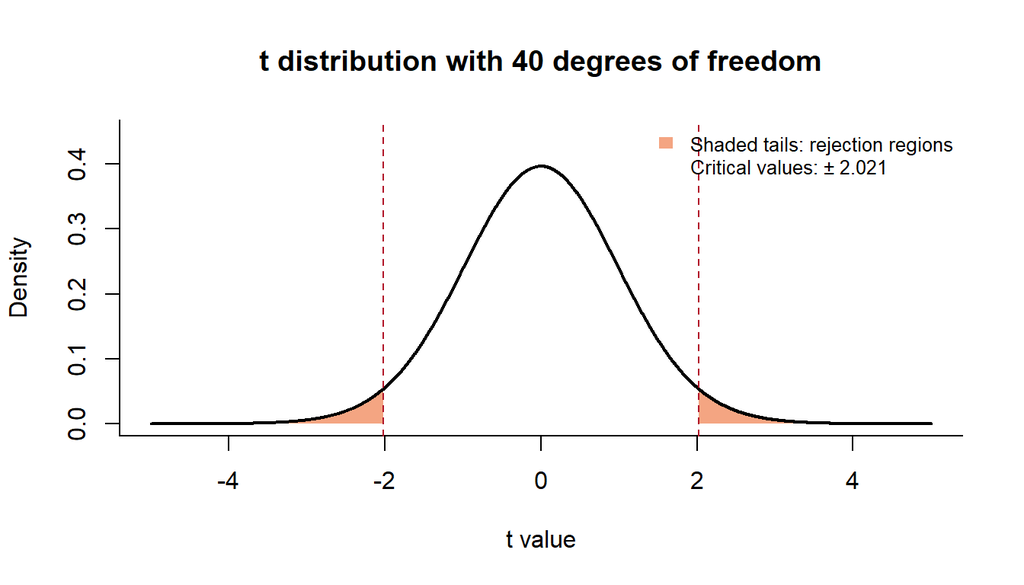

**df = 60**

Use this table when your degrees of freedom equal 60. Compare your absolute t value with the critical values below and read across to find the two-tailed probability.

| Critical \|t\| | Two-tailed probability |
| --- | --- |
| 0.679 | 0.500 |
| 0.848 | 0.400 |
| 1.045 | 0.300 |
| 1.162 | 0.250 |
| 1.296 | 0.200 |
| 1.326 | 0.190 |
| 1.357 | 0.180 |
| 1.389 | 0.170 |
| 1.423 | 0.160 |
| 1.458 | 0.150 |
| 1.496 | 0.140 |
| 1.535 | 0.130 |
| 1.577 | 0.120 |
| 1.622 | 0.110 |
| 1.671 | 0.100 |
| 1.723 | 0.090 |
| 1.781 | 0.080 |
| 1.845 | 0.070 |
| 1.917 | 0.060 |
| 2.000 | 0.050 |
| 2.047 | 0.045 |
| 2.099 | 0.040 |
| 2.157 | 0.035 |
| 2.223 | 0.030 |
| 2.299 | 0.025 |
| 2.390 | 0.020 |
| 2.504 | 0.015 |
| 2.660 | 0.010 |
| 2.744 | 0.008 |
| 2.849 | 0.006 |
| 2.994 | 0.004 |
| 3.232 | 0.002 |
| 3.460 | 0.001 |

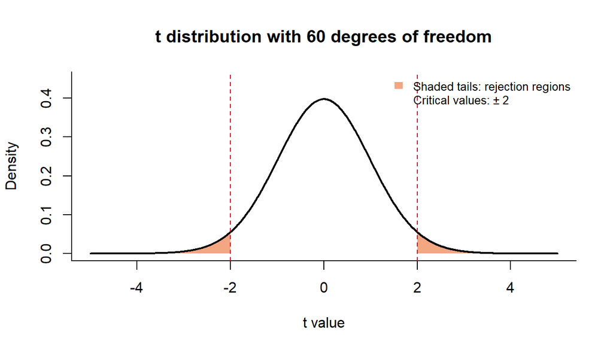

**df = 100**

Use this table when your degrees of freedom equal 100. Compare your absolute t value with the critical values below and read across to find the two-tailed probability.

| Critical \|t\| | Two-tailed probability |
| --- | --- |
| 0.677 | 0.500 |
| 0.845 | 0.400 |
| 1.042 | 0.300 |
| 1.157 | 0.250 |
| 1.290 | 0.200 |
| 1.320 | 0.190 |
| 1.350 | 0.180 |
| 1.382 | 0.170 |
| 1.416 | 0.160 |
| 1.451 | 0.150 |
| 1.488 | 0.140 |
| 1.527 | 0.130 |
| 1.568 | 0.120 |
| 1.613 | 0.110 |
| 1.660 | 0.100 |
| 1.712 | 0.090 |
| 1.769 | 0.080 |
| 1.832 | 0.070 |
| 1.902 | 0.060 |
| 1.984 | 0.050 |
| 2.030 | 0.045 |
| 2.081 | 0.040 |
| 2.137 | 0.035 |
| 2.201 | 0.030 |
| 2.276 | 0.025 |
| 2.364 | 0.020 |
| 2.475 | 0.015 |
| 2.626 | 0.010 |
| 2.706 | 0.008 |
| 2.808 | 0.006 |
| 2.946 | 0.004 |
| 3.174 | 0.002 |
| 3.390 | 0.001 |

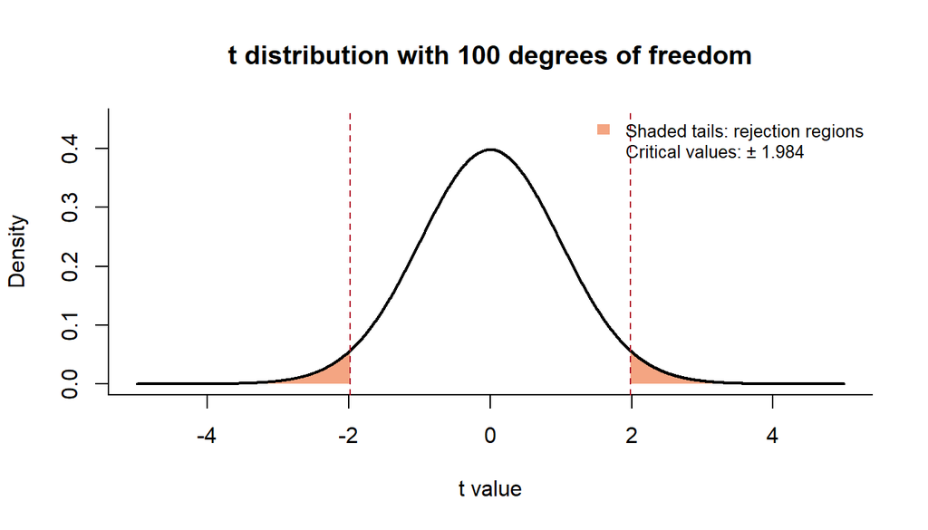

**df = 200**

Use this table when your degrees of freedom equal 200. Compare your absolute t value with the critical values below and read across to find the two-tailed probability.

| Critical \|t\| | Two-tailed probability |
| --- | --- |
| 0.676 | 0.500 |
| 0.843 | 0.400 |
| 1.039 | 0.300 |
| 1.154 | 0.250 |
| 1.286 | 0.200 |
| 1.315 | 0.190 |
| 1.345 | 0.180 |
| 1.377 | 0.170 |
| 1.410 | 0.160 |
| 1.445 | 0.150 |
| 1.482 | 0.140 |
| 1.520 | 0.130 |
| 1.561 | 0.120 |
| 1.605 | 0.110 |
| 1.653 | 0.100 |
| 1.704 | 0.090 |
| 1.760 | 0.080 |
| 1.822 | 0.070 |
| 1.892 | 0.060 |
| 1.972 | 0.050 |
| 2.017 | 0.045 |
| 2.067 | 0.040 |
| 2.123 | 0.035 |
| 2.186 | 0.030 |
| 2.258 | 0.025 |
| 2.345 | 0.020 |
| 2.454 | 0.015 |
| 2.601 | 0.010 |
| 2.679 | 0.008 |
| 2.777 | 0.006 |
| 2.912 | 0.004 |
| 3.131 | 0.002 |
| 3.340 | 0.001 |

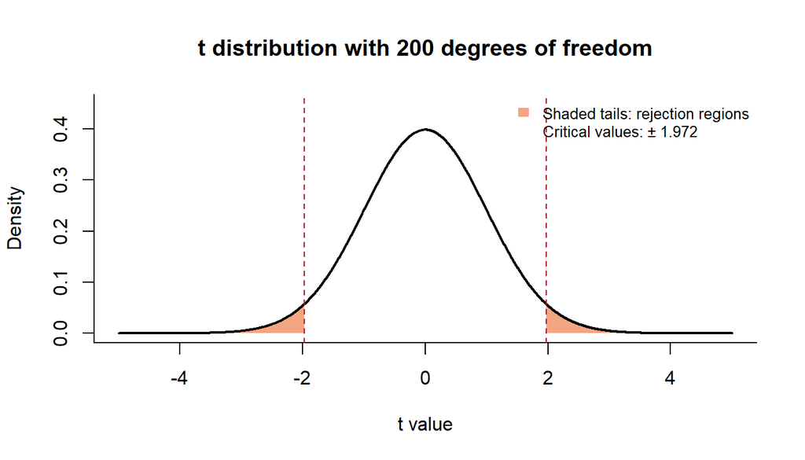

### Task 3.2 Exact P-value

#### Excel 💻

In Excel, use:

```
=T.DIST.2T(ABS(t),df)
```

Replace `t` and `df` with your values or the cells containing them.

This function gives the two-tailed P-value.

If you are working by hand, complete this step later when you have access to a computer.

Report your P-value. Does it fall within the range you found using the table?

## Task 4

Make your statistical decision using $\alpha = 0.05$.

Do you reject or fail to reject the null hypothesis? Explain what your decision means for the claim that the population mean body temperature is 98.6°F.

## Task 5

#### 💻 Run this task in **R**

**WarningDownload the data again before starting in R**

Re-download `datatable.csv` from Canvas and save it in your R project folder. **Do not use the file you modified in Excel**, as those changes can cause issues when reading and analyzing the data in R.

First, read the data into an object called `res`. Make sure `datatable.csv` is in your project folder.

```r
library(readr)

res <- read_csv("datatable.csv")

# Check the column names and the first few rows.
names(res)
head(res)
```

**ImportantCalculate it step by step**

For this task, calculate the mean, standard deviation, standard error, t value, and P-value step by step. Do not use `t.test()` yet! You will use it in Task 5.1 to check your calculations.

Calculate the mean using `mean()`, calculate the standard deviation using `sd()`, and calculate the standard error.

Then calculate your t value.

```r
n <- length(res$temperature)

sample_mean <- mean(res$temperature)
sample_sd <- sd(res$temperature)

# Replace NA with your calculations.
standard_error <- NA
t_value <- NA
```

Find the two-tailed P-value using:

```r
2 * pt(q = abs(t_value), df = n - 1, lower.tail = FALSE)
```

Compare your results with your earlier calculations.

### Task 5.1 Run the whole test in R

#### 💻 Run this task in **R**.

Run:

```r
t.test(res$temperature, mu = 98.6, alternative = "two.sided")
```

Find the t value, degrees of freedom, and P-value in the output. Do they match your calculations?

## Task 6

#### 💻 Run this task in **R**.

Plot the t distribution, rejection regions, and your observed t value.

If the population mean temperature truly is 98.6°F, imagine repeatedly taking random samples of 25 people and calculating a t value for each sample. Assuming population temperatures are normally distributed, these values follow a t distribution with 24 degrees of freedom.

The shaded regions below represent the rejection regions for a two-tailed test with $\alpha = 0.05$. Each tail contains 0.025 of the total area.

Replace the first `NA` with your degrees of freedom and the second `NA` with your calculated t value.

```r
# Replace these two values.
df <- NA
t_value <- NA

# Find the critical t value for a two-tailed test.
alpha <- 0.05
critical_t <- qt(1 - alpha / 2, df = df)

# Set the horizontal range.
x_limit <- max(4, abs(t_value) + 1, critical_t + 1)
x <- seq(-x_limit, x_limit, length.out = 2001)

# Draw the t distribution.
plot(
  x, dt(x, df = df),
  type = "n",
  main = "t distribution if the population mean is 98.6°F",
  xlab = "t value",
  ylab = "Density",
  bty = "l"
)

# Shade the rejection regions for alpha = 0.05.
left_tail <- seq(-x_limit, -critical_t, length.out = 500)
right_tail <- seq(critical_t, x_limit, length.out = 500)

polygon(
  c(left_tail, rev(left_tail)),
  c(dt(left_tail, df = df), rep(0, length(left_tail))),
  col = "#92C5DE",
  border = NA
)

polygon(
  c(right_tail, rev(right_tail)),
  c(dt(right_tail, df = df), rep(0, length(right_tail))),
  col = "#92C5DE",
  border = NA
)

# Add the distribution curve.
lines(x, dt(x, df = df), lwd = 2)

# Mark the boundaries of the rejection regions.
abline(
  v = c(-critical_t, critical_t),
  col = "gray40",
  lty = 3
)

# Mark the observed t value and its opposite.
abline(v = t_value, col = "#B2182B", lwd = 2)
abline(v = -t_value, col = "#B2182B", lty = 2, lwd = 2)

legend(
  "topright",
  legend = c(
    "Observed t value",
    "Equally extreme value",
    "Critical values"
  ),
  col = c("#B2182B", "#B2182B", "gray40"),
  lty = c(1, 2, 3),
  lwd = c(2, 2, 1),
  bty = "n",
  cex = 0.8
)

mtext(
  paste0(
    "Shaded rejection regions: alpha = 0.05; critical values = ±",
    round(critical_t, 3)
  ),
  side = 3,
  line = 0.3,
  cex = 0.8
)
```

### How to interpret your graph

The solid red line marks your observed t value. The dashed red line marks an equally extreme value on the opposite side of zero. The dotted gray lines mark the critical values.

If your observed t value falls in either shaded region, it is among the most extreme 5% of t values expected under the null hypothesis. **Reject the null hypothesis** at $\alpha = 0.05$.

If your observed t value falls between the critical values, **fail to reject the null hypothesis**. Your sample does not provide sufficient evidence that the population mean differs from 98.6°F. This does not establish that the population mean equals 98.6°F.

The shaded area is fixed at 0.05. Your P-value is the area beyond your observed t value and the equally extreme value in the opposite tail.

**Use your graph to explain your decision in two or three sentences.** Describe where your observed t value falls relative to the rejection regions, explain why you rejected or failed to reject the null hypothesis, and state what this means for the population mean body temperature.